# MasterControl QAL Analysis - EDA

# Chunk 6: Mx Performance by Company Size

```r
# First create df_classified (in case it's not in environment)
df_classified <- df %>%
  mutate(
    product_group = case_when(
      solution %in% c("Mx", "Manufacturing") ~ "Mx",
      solution %in% c("Qx", "Quality") ~ "Qx",
      TRUE ~ "Other"
    )
  )

# Now analyze Mx by company tier
mx_tier <- df_classified %>%
  filter(product_group == "Mx",
         !is.na(`acct tier rollup`),
         `acct tier rollup` != "Other") %>%
  group_by(`acct tier rollup`) %>%
  summarise(
    total = n(),
    sql = sum(`next_stage__c` == "SQL", na.rm = TRUE),
    rate = round(100 * sql / total, 1)
  ) %>%
  arrange(desc(rate))

kable(mx_tier, caption = "Mx Conversion by Company Size")
```

Mx Conversion by Company Size

| acct tier rollup | total | sql | rate |
| --- | --- | --- | --- |
| Small | 846 | 132 | 15.6 |
| Medium | 2281 | 248 | 10.9 |
| Large | 542 | 30 | 5.5 |

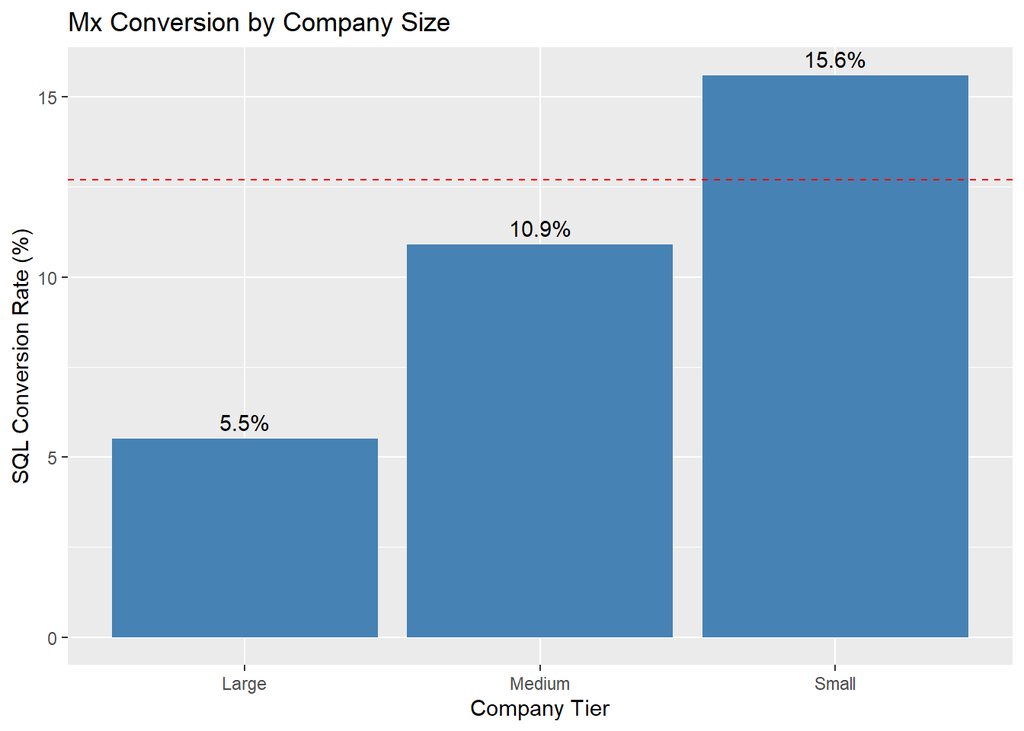

```r
# Plot
mx_tier %>%
  ggplot(aes(x = reorder(`acct tier rollup`, rate), y = rate)) +
  geom_col(fill = "steelblue") +
  geom_hline(yintercept = 12.7, linetype = "dashed", color = "red") +
  geom_text(aes(label = paste0(rate, "%")), vjust = -0.5) +
  labs(title = "Mx Conversion by Company Size",
       x = "Company Tier", y = "SQL Conversion Rate (%)")
```

**Notes - Company Size Impact**

Surprising finding: **Small companies convert best** for Mx at 15.6% - above the 12.7% baseline. - Small: 15.6% (846 leads) - Medium: 10.9% (2,281 leads) - Large: 5.5% (542 leads)

This is the opposite of what I expected. Figured bigger manufacturers would have more complex operations needing MES software.

**Possible explanations:** - Small companies might be more agile, easier to sell to (fewer decision-makers?) - Large companies might already have MES systems in place - harder to displace - Medium/Large might have more complex buying processes that kill deals

**Volume consideration:** Small companies have both the best conversion (15.6%) AND decent volume (846 leads). Medium has the most volume (2,281) but converts poorly (10.9%).

Using MasterControl’s “25% with 1,000 vs 50% with 50” principle: Small companies look like the sweet spot - above-baseline conversion with sufficient volume.

**This changes my thinking:** I assumed we’d want to target Large manufacturers for Mx, but the data says focus on Small companies instead. Need to understand why Large underperforms so badly (5.5% is less than half the baseline).

# Chunk 5: Title Data Quality Check

```r
title_summary <- df %>%
  summarise(
    total = n(),
    with_title = sum(!is.na(`contact/lead title`)),
    missing = sum(is.na(`contact/lead title`)),
    pct_missing = round(100 * missing / total, 1),
    unique_titles = n_distinct(`contact/lead title`, na.rm = TRUE)
  )

cat("Title Summary:\n")
```

```
## Title Summary:
```

```r
cat("  Total leads:", comma(title_summary$total), "\n")
```

```
##   Total leads: 16,815
```

```r
cat("  With titles:", comma(title_summary$with_title), "\n")
```

```
##   With titles: 10,407
```

```r
cat("  Missing:", comma(title_summary$missing),
    paste0("(", title_summary$pct_missing, "%)"), "\n")
```

```
##   Missing: 6,408 (38.1%)
```

```r
cat("  Unique titles:", comma(title_summary$unique_titles), "\n")
```

```
##   Unique titles: 5,790
```

**Notes - Title Challenge**

5,790 unique title variations. That’s the problem - no standardization.

38.1% are missing entirely (6,408 records). For the 10,407 that do have titles, need to extract patterns: - Seniority (C-Suite, VP, Director, Manager, IC) - Function (Quality, Operations, Engineering, Regulatory)

This is going to require keyword matching. Can’t manually categorize 5,790 variations.

The missing 38% will limit title-based segmentation - any analysis by job title only covers 62% of leads. Similar issue to the manufacturing model missing data.

## **Next step:** Look at most common titles to identify keyword patterns I can use for classification.iuk

# Chunk 6: Most Common Titles

```r
# Top 30 titles
top_titles <- df %>%
  filter(!is.na(`contact/lead title`)) %>%
  count(`contact/lead title`, sort = TRUE) %>%
  head(30)

kable(top_titles, caption = "Top 30 Job Titles by Frequency")
```

Top 30 Job Titles by Frequency

| contact/lead title | n |
| --- | --- |
| Quality Manager | 252 |
| Manager, Quality | 124 |
| Quality Assurance Manager | 98 |
| Manager, Quality Assurance | 94 |
| Quality Engineer | 84 |
| QA Manager | 72 |
| Consultant | 69 |
| Director | 65 |
| CEO | 64 |
| Project Manager | 61 |
| Quality Assurance Specialist | 60 |
| Director, Quality | 59 |
| President | 51 |
| Manager | 46 |
| Managing Director | 44 |
| Chief Operating Officer | 42 |
| Director, Operations | 36 |
| Manager, Operations | 36 |
| Quality Specialist | 36 |
| Head of Quality | 35 |
| Production Manager | 35 |
| Director of Quality | 32 |
| Director, Information Technology | 30 |
| Chief Executive Officer | 29 |
| Director, Quality Assurance | 28 |
| Quality Control Manager | 28 |
| Quality Director | 28 |
| IT Manager | 27 |
| Senior Manager | 27 |
| Senior Quality Engineer | 27 |

```r
# Check for keyword patterns
keywords <- c("quality", "manager", "director", "engineer", "vp", "president",
              "operations", "manufacturing", "regulatory", "senior")

# Count how often each keyword appears
keyword_counts <- tibble(
  keyword = keywords,
  count = map_dbl(keywords, ~sum(str_detect(
    tolower(df$`contact/lead title`[!is.na(df$`contact/lead title`)]), .x
  )))
) %>%
  arrange(desc(count))

kable(keyword_counts, caption = "Keyword Frequency in Titles")
```

Keyword Frequency in Titles

| keyword | count |
| --- | --- |
| manager | 3119 |
| quality | 3096 |
| director | 1746 |
| senior | 1082 |
| engineer | 987 |
| operations | 774 |
| manufacturing | 477 |
| regulatory | 460 |
| president | 458 |
| vp | 89 |

**Notes - Title Patterns**

Clear patterns emerging from the top 30 titles and keyword analysis:

**Most common titles are Quality-focused:** - Quality Manager (252) - Manager, Quality (124) - Quality Assurance Manager (98) - QA Manager (72)

Makes sense given MasterControl’s customer base, but this is a problem for Mx - these are Quality personas, not Manufacturing personas.

**Keyword frequency shows I can build a classification system:**

**For Seniority:** - manager: 3,119 occurrences - director: 1,746 - senior: 1,082 - president: 458 - vp: 89

**For Function:** - quality: 3,096 (dominant) - operations: 774 - manufacturing: 477 - regulatory: 460 - engineer: 987

**Classification approach:** Build hierarchical logic: 1. Check for C-Suite keywords (CEO, President, Founder) → C-Suite 2. Check for VP → VP 3. Check for Director → Director  
4. Check for Manager → Manager 5. Check for Senior → Senior IC 6. Everything else → IC or Unknown

Similar approach for function - check for quality, operations, manufacturing, regulatory, engineering keywords.

**Key insight:** Quality titles dominate (3,096 “quality” vs 477 “manufacturing”). This explains the Mx problem - we’re reaching Quality personas who care about QMS, not Manufacturing personas who need MES.

## Option C: Segment Identification

# Chunk 5: Combined Segmentation (Industry × Size × Product)

```r
# Find high-performing combinations
segments <- df_classified %>%
  filter(!is.na(`acct target industry`),
         !is.na(`acct tier rollup`),
         `acct tier rollup` != "Other",
         product_group %in% c("Mx", "Qx")) %>%
  group_by(`acct target industry`, `acct tier rollup`, product_group) %>%
  summarise(
    total = n(),
    sql = sum(`next_stage__c` == "SQL", na.rm = TRUE),
    rate = round(100 * sql / total, 1),
    .groups = "drop"
  ) %>%
  filter(total >= 30) %>%  # Need statistical confidence
  arrange(desc(rate))

# Show top 20
kable(head(segments, 20),
      caption = "Top 20 Segments (Industry × Size × Product, min 30 leads)")
```

Top 20 Segments (Industry × Size × Product, min 30 leads)

| acct target industry | acct tier rollup | product_group | total | sql | rate |
| --- | --- | --- | --- | --- | --- |
| Medical Device | Small | Qx | 804 | 232 | 28.9 |
| Blood & Biologics | Small | Qx | 130 | 34 | 26.2 |
| Pharma & BioTech | Small | Qx | 855 | 215 | 25.1 |
| Blood & Biologics | Medium | Qx | 148 | 31 | 20.9 |
| Medical Device | Small | Mx | 192 | 39 | 20.3 |
| Pharma & BioTech | Small | Mx | 326 | 62 | 19.0 |
| Medical Device | Medium | Qx | 1331 | 250 | 18.8 |
| Non-Life Science | Medium | Qx | 2476 | 456 | 18.4 |
| Pharma & BioTech | Medium | Qx | 2237 | 384 | 17.2 |
| Non-Life Science | Medium | Mx | 545 | 69 | 12.7 |
| Medical Device | Medium | Mx | 546 | 69 | 12.6 |
| Blood & Biologics | Large | Qx | 40 | 5 | 12.5 |
| Non-Life Science | Large | Qx | 493 | 56 | 11.4 |
| Blood & Biologics | Medium | Mx | 45 | 5 | 11.1 |
| Non-Life Science | Small | Qx | 1249 | 131 | 10.5 |
| Pharma & BioTech | Medium | Mx | 1135 | 105 | 9.3 |
| Pharma & BioTech | Large | Qx | 555 | 50 | 9.0 |
| Non-Life Science | Small | Mx | 295 | 25 | 8.5 |
| Medical Device | Large | Qx | 296 | 25 | 8.4 |
| Medical Device | Large | Mx | 118 | 7 | 5.9 |

**Notes - High-Performing Segments**

Looking at the top combinations:

**Best overall:** Medical Device + Small + Qx converts at 28.9% (804 leads) - way above baseline.

**Best Mx segments:** - Medical Device + Small + Mx: 20.3% (192 leads) ← Best Mx performance I’ve seen - Pharma + Small + Mx: 19.0% (326 leads) ← Also strong, decent volume

**Interesting finding:** Pharma + Small + Mx converts at 19.0%, but earlier I saw overall Pharma + Mx was only 10.4%. The difference? Company size. Small pharma companies work for Mx, medium/large pharma don’t.

**Volume consideration:** - Medical Device + Small + Mx: 20.3% conversion with 192 leads - above baseline, decent volume - Pharma + Small + Mx: 19.0% with 326 leads - even better volume

These are actionable segments. Both have sufficient volume (>100 leads) and beat the 12.7% Mx baseline significantly.

;—

# AI Usage Log

I leveraged AI assistance for coding support and exploratory guidance. The business insights and recommendations reflect my analysis of the findings.

**END OF EDA**